NOTE : for better user experience, this notebook uses the Python Markdown Jupyter Notebook extension (@see the corresponding [ReadTheDoc page](https://jupyter-contrib-nbextensions.readthedocs.io/en/latest/nbextensions/python-markdown/readme.html) and the associated [GitHub repo](https://github.com/ipython-contrib/jupyter_contrib_nbextensions) for details). Please make sure it is installed and activated on your environment and that the current notebook is set as "Trusted" for it to work.

# Sentiment Analysis in French

## 0. Introduction

We will be performing sentiment analysis on Tweeter data from the open dataset by Charles MALAFOSSE which can be found on the following [GitHub page](https://github.com/charlesmalafosse/open-dataset-for-sentiment-analysis?files=1). Sentiment is there categorized as either POSITIVE, NEGATIVE, or NEUTRAL.  
As we're focusing on NLP Sentiment Classification in French language, we will only consider the 250,000 tweets in French language from that dataset.

```
As we will explain in the upcoming sections, we will be training a dual bidirectional-GRU NLP model (@see chapter §4.) using fastText French word embeddings (@see chapter §3.) and transfer learning (@see chapter §2.). It will be first done using review data that we have scrapped from the Web (@see chapter §2.1.), and then again on the French Tweets dataset (@see chapters §1. and §5.2.a).

This will translate in 3 steps as described in the below figure : i) pre-training, ii) warming-up and iii) fine-tuning.
```

[figure not shown]

One important note : when training our model following the above-depicted 3-steps, the only difference beween the step 1 on one hand (pre-training) and steps 2 & 3 on the other (warming-up & fine tuning) consists in the model output layer.  
It is important to note that the entire data pipeline otherwise remains identical. Neither the pre-processing nor the text tokenization, nor the dimensions of the model input layer (max number of tokens in the imput text) are modified.

1. The Dataset  
   1.1. Pre-processing  
   1.2. Domain-specificity  
   1.3. High Imbalance Characteristic
2. Transfer Learning  
   2.1. Web Scraping  
   2.2. Custom Text Tokenizer
3. Word Embeddings  
   3.1. fastText  
   3.2. The <UKN> Token
4. Dual bi-GRU NLP Model  
   4.1. Architecture  
   4.2. Hyperparameters optimization
5. NLP Model Training  
   5.1. Pre-training  
   5.2. Warming-Up  
   5.3. Fine-tuning
6. Conclusion

## 1. The Dataset *(go back to top ↑)]*

```python
import os, gc, datetime
import base64, cv2

import numpy as np
np.set_printoptions(suppress=True) #prevent numpy exponential
                                   #notation on print
import pandas as pd

import matplotlib.pyplot as plt
plt.rcParams.update({'font.size': 12})
%matplotlib inline

%reload_ext autoreload
%autoreload 2

from my_NLP_RNN_fr_lib.tweet_utils import \
    TWEET_MAX_CHAR_COUNT, html_escape
```

```python
%%html
<style type='text/css'>
.CodeMirror{
font-size: 8.5pt;
}</style>
```

First, let us download French Tweets dataset, which consists of 3 zip files :

```python
from my_NLP_RNN_fr_lib.tweet_utils import download_tweet_fr ; download_tweet_fr()
```

```python
from my_NLP_RNN_fr_lib.tweet_utils import load_tweet_fr ; tweets = load_tweet_fr()
```

```
Loaded the dataset in 2.6395 seconds
```

### 1.1. Pre-processing *(go back to top ↑)]*

As far as data cleaning goes, we ensure that :

- no '@' mention,
- no URL link,
- no html tag,
- no special character (such as 'œ', which we replace with 'oe') and
- no duplicate posts

remain in the body of the French Tweets we feed our model. This information does indeed not add value to build a Sentiment Analysis model.  
In addition to that, we also deal with hashtags (#) in a manner such that we get the better out of them. Below we can see 2 examples of how we handle them :

```python
from my_NLP_RNN_fr_lib.tweet_utils import hashtag_converter_tweet_fr
from my_NLP_RNN_fr_lib.display_helper import dataframe_pretty_print_center

dummy_tweet_df = pd.DataFrame({'tweet_text':
                               [html_escape('Allez #tousAvecLesBleus, gÃ©nial!'), html_escape("#AllezLePSG")]})
result_df = pd.concat(
    [dummy_tweet_df, hashtag_converter_tweet_fr(dummy_tweet_df[ 'tweet_text' ])], axis = 1 )
result_df.columns = [ 'original', 'converted' ]
dataframe_pretty_print_center(result_df) ; del result_df
```

| original | converted |
| --- | --- |
| Allez #tousAvecLesBleus, génial! | Allez tous Avec Les Bleus, génial! |
| #AllezLePSG | Allez Le PSG |

Lets apply this data pre-processing to the whole dataset, then :

```python
from my_NLP_RNN_fr_lib.tweet_utils import clean_tweet_fr ; tweets = clean_tweet_fr(tweets)
```

```python
tweets_count = tweets.shape[0]
tweets.drop( tweets[tweets[ 'tweet_text' ].map(
    lambda txt: len(str(txt))) > TWEET_MAX_CHAR_COUNT].index, inplace=True )
tweets.reset_index(drop=True, inplace=True)
dropped_tweets_count = tweets_count - tweets.shape[0]
```

After the pre-processing of the French Twitter dataset, 287 entries unfortunately ended up being more than 280 characters long, mostly as a result of hashtags words splitting. In an effort to keeping things simple, we dropped those tweets (which barely accounted for 0.13% of the entire dataset).

REMARK : any real-life entry that would exceed this max length would be truncated (as part of the **my_NLP_RNN_fr_lib.fastText.sentences_to_indices** input procedure).

### 1.2. Domain-specificity *(go back to top ↑)]*

By design, the French Tweets dataset we're using is specific to soccer. To that extent, it can be considered to be domain-specific .  
Below are displayed 3 random tweets from that dataset :

```python
import random
from IPython.display import Markdown, display
def printmd(string):
    # @see 'https://stackoverflow.com/questions/23271575#46934204'
    # (printing-bold-colored-etc-text-in-ipython-qtconsole)
    display(Markdown(string))

dummy = [printmd('<div style="margin-left:45px;text-align: justify;">' +
                 '<span style="color:darkred;padding-left:45px">' +
                 " - " + html_escape(tweet['tweet_text']) + "</span></div>\n" )
         for i, tweet in
         tweets.iloc[random.sample(range(0, tweets.shape[0]-1), tweets_sample_size)].iterrows()]
```

- ?? Allez les bleus?? Nice Magnifique France Nice 06 Nice Moments Nissa La Bella frenchriviera I Lovenice Coted Azur France Metropole NCA

- On regrette que tu n'aies pas été là pour ce match, quoique, c'est pas tout à fait sûr ?. Rendez -vous au Parc ?

- Encore 8 ?? 5 ?? jours ou je vais mentionner ? pour qu'il m'envoie son maillot ! ?? Mendy Manchester City

### 1.3. High Imbalance Characteristic *(go back to top ↑)]*

highly inbalanced => downsampling => small dataset => need for transfer learning (from "generic" domain [resto+movies+appliances] to domain-specific [soccer])

Lets have a look at how tweets are distributed among the three classes that are "NEGATIVE", "NEUTRAL" and "POSITIVE" :

| sentiment | count | percentage |
| --- | --- | --- |
| NEGATIVE | 6,069 | 2.76% |
| NEUTRAL | 182,049 | 82.90% |
| POSITIVE | 31,481 | 14.34% |

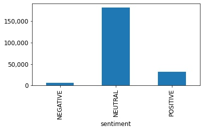

```python
from my_NLP_RNN_fr_lib.display_helper import two_columns_display__classes_distribution

two_columns_display__classes_distribution( tweets[['sentiment']] )
```

## 2. Transfer Learning *(go back to top ↑)]*

### 2.1. Web Scraping *(go back to top ↑)]*

In order to train a model with the highest predictive power, we turn towards transfer learning from a domain as generic as possible.  
For that purpose, we scrapped the web using the BeautifullSoup python library (https://pypi.org/project/beautifulsoup4/), which basically provides convenience methods to scan thru web pages via an HTML/XML parser.  
We collected review data from the web on the three below broad product families :

1. bars & restaurants (across french cities)
   1. casual dining
   2. family style
   3. cafeteria
   4. brasserie and bistro
   5. coffee house
   6. wine bar
   7. etc.
2. movies (french and international)
   1. action
   2. anime
   3. adventure
   4. ...
   5. historical film
   6. psychological movie
   7. romantic movie.
   8. ...
3. appliances & electronics (french market)
   1. large appliances (washing machine, fridge, oven, etc)
   2. kitchen and cooking
   3. video-game console
   4. tablet, smartphone, connected object
   5. computers
   6. video & stereo

Lets load and apply the same pre-processing as before to it :

```python
from my_NLP_RNN_fr_lib.tweet_utils import load_review_fr

reviews = load_review_fr()
```

```
Loaded the dataset in 1.7199 seconds
```

```python
reviews = clean_tweet_fr(reviews, col_name = 'comment')
```

```python
from my_NLP_RNN_fr_lib.display_helper import two_columns_display

df = reviews[[ 'type', 'rating' ]].groupby('type').count().rename(columns = {'rating':'count'})
df[ 'percentage' ] = (df / len( reviews ) * 100)['count']
df_html = df.reset_index(level=0).style.hide_index() \
    .set_properties(**{'width':'20em', 'text-align':'center'}) \
    .format({"count": "{:20,.0f}", "percentage": "{0:.2f}%"}) \
    .set_table_styles([dict(selector="th", props=[('text-align', 'center')])]).render()
two_columns_display(df_html, '', 1)
```

| type | count | percentage |
| --- | --- | --- |
| appliances_n_electronics | 37,096 | 21.30% |
| bars_n_restaurants | 48,664 | 27.94% |
| movies | 88,418 | 50.76% |

Contrarily to the French Tweets dataset which has 3 classes (NEGATIVE/NEUTRAL/POSITIVE), the French Reviews dataset has 5 classes. The commented reviews are indeed here accompanied by a score between 1 and 5 :

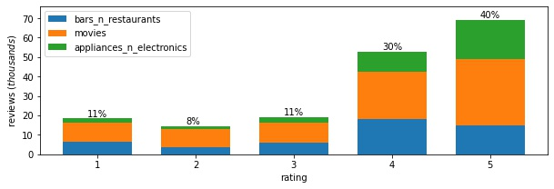

```python
from matplotlib.ticker import FuncFormatter

hist1, bins = np.histogram(
    reviews[(reviews['type'] == 'bars_n_restaurants')]['rating']
    , bins = 5, range = (1, 6))
hist2, bins = np.histogram(
    reviews[(reviews['type'] == 'movies')]['rating']
    , bins = 5, range = (1, 6))
hist3, bins = np.histogram(
    reviews[(reviews['type'] == 'appliances_n_electronics')]['rating']
    , bins = 5, range = (1, 6))

normalized_hist = \
    (hist1+hist2+hist3).astype(np.float32) / (hist1.sum()+hist2.sum()+hist3.sum())

plt.ioff() ; fig = plt.figure(figsize=(10, 3))
width = .7 ; center = list(range(1, 6, 1))
bar1 = plt.bar(center, hist1, align='center', width=width)
bar2 = plt.bar(center, hist2, align='center', width=width, bottom=hist1)
bar3 = plt.bar(center, hist3, align='center', width=width, bottom=hist1+hist2)
ax = plt.gca()
ax.get_yaxis().set_major_formatter(
    FuncFormatter(lambda y, p: str(int(y/1000)) ))

plt.ylabel( "reviews $\it{(thousands)}$" )
plt.xlabel( "rating" )
plt.legend((bar1[0], bar2[0], bar3[0])
           , ('bars_n_restaurants', 'movies', 'appliances_n_electronics'))

for i in range(0, 5):
    x = center[i]
    y = hist1[i]+hist2[i]+hist3[i]
    ax.annotate( "{0:.0%}".format( normalized_hist[i] ), (x-.1, y+1000) )

ax.set_ylim([0, ax.get_ylim()[1]*1.05]) ; #plt.show()
fig_url = os.path.join('tmp', "reviews_dataset.jpg")
plt.savefig(fig_url, bbox_inches='tight') ; plt.close(fig)

# use base64 encoding to circumvent image (external file) caching (webbrowser)
with open(fig_url, "rb") as image_file:
    encoded_string = base64.b64encode(image_file.read())
encoded_string = "data:… " + encoded_string.decode()
os.remove(fig_url)

two_columns_display(
    '<div style="text-align: center;"><img style="display: inline-block;" src="' +
    encoded_string + '" /></div>', '', 1)
```

We will treat this Sentiment Classification problem as a regression problem (we treat the "rating" variable as a continuous variable). That way, our model will be highly penalized if it classifies a "5 stars" product review as a "1 star" product review (even more so than if the matter was dealt with as a pure classification problem) since the objective function will bring to minimizing the distance between the prediction and the real rating (as opposed to simply categorizing a rating in the proper class).  
Note that, however imbalanced to a certain extend, the French Reviews is way less so than the French Tweets dataset.

### 2.2. Custom Text Tokenizer *(go back to top ↑)]*

We will be using a custom tokenizer for our datasets. It uses a regex pattern which has a few specificities to better take advantage of the raw text comments we are encountering in real life.  
Most of those specificities have to do with quantities, units, and whether or not the two are space-separated. We deam those specificities important since many times in the French Reviews dataset, prices, volumes, weights and distances do count in the satisfaction one has with regards to a product that is being rated and commented. We want to optimize the chances for our model to grab those relations not less than any other.  
Lets apply this tokenizer to our French Tweets dataset and look at the tokens distribution accros our records :

```python
from my_NLP_RNN_fr_lib.tokenizer_utils import tokenize_tweet_fr

tokenized_tweets = tokenize_tweet_fr(tweets)
#del tweets ; silent = gc.collect()
```

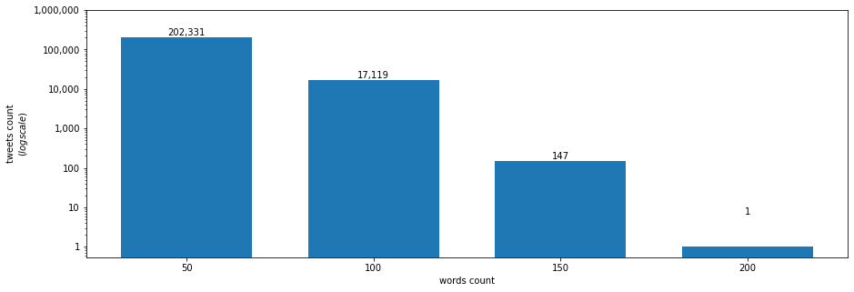

```python
from my_NLP_RNN_fr_lib.tweet_utils import plt_hist_bin_width

tweet_length_data = tokenized_tweets.map( lambda words_list: len( words_list ) )
binwidth = 50
ax = plt_hist_bin_width( data = tweet_length_data, binwidth = binwidth
                         , ylog = True, rotate_text = False )
ax.set_ylabel('tweets count\n($\it{log scale}$)')
ax.set_xlabel('words count')
plt.show()

max_length = np.arange(min(tweet_length_data), max(tweet_length_data) + binwidth, binwidth)[-1]
tweets_count = tweet_length_data.map(
    lambda tweet_length: (tweet_length <= max_length) & (tweet_length > max_length-binwidth)
).sum()
del tokenized_tweets, tweet_length_data ; dummy = gc.collect()
```

```python
tokenized_reviews = tokenize_tweet_fr(reviews, col_name='comment')
```

```python
reviews_length_data = \
    tokenized_reviews.map( lambda sentence_tokens_list: len( sentence_tokens_list ) )
reviews_count = tokenized_reviews.shape[0]
reviews.drop(
    reviews_length_data[
        (reviews_length_data > TWEET_MAX_CHAR_COUNT) | (reviews_length_data == 0)
    ].index
    , inplace=True )
reviews.reset_index(drop=True, inplace=True)
dropped_reviews_count = reviews_count - tokenized_reviews.shape[0]
del tokenized_reviews, reviews_length_data ; dummy = gc.collect()
```

```python
# data sanity check ; ensure no "rating" is malformed =>
assert (not reviews['rating'].isnull().any() and
        np.issubdtype(reviews['rating'].dtype, np.number)) \
    , 'we have a "rating is malformed" issue with the training data !'
```

## 3. Word Embeddings *(go back to top ↑)]*

### 3.1. fastText *(go back to top ↑)]*

We're using word embeddings from fastText. They have been generated by training fastText NLP models on text gethered from [Common Crawl](https://commoncrawl.org/) and [Wikipedia](https://www.wikipedia.org/). For more on this, please visit https://fasttext.cc/docs/en/crawl-vectors.html

```python
from my_NLP_RNN_fr_lib.fastText import download_fastText_fr_300_vec ; download_fastText_fr_300_vec()
```

```python
from my_NLP_RNN_fr_lib.fastText import read_fastText_vecs

word_to_index, index_to_word, word_to_vec_map = \
    read_fastText_vecs( os.path.join('data', 'fastText_french', 'cc.fr.300.vec') )
```

```
Loaded the Vocabulary in 138.4681 seconds [1,234,042 word embeddings of 300 features]
```

Our vocabulary is comprised of 1,234,043 words and the shape of a word vector is "(300,)", meaning each token is codified in a 300 dimensions space.

### 3.2. The <UKN> Token *(go back to top ↑)]*

Below, we calculate the dimensions for the vector associated to the "<UKN>" token. This "<UKN>" token will serve as a placeholder for any word encountered that does not belong to our vocabulary. For instance, when a word is mis-spelled, it probably doesn't belong to our vocabulary. We then associate it to the "<UKN>" ("unknown") token prior to feeding it to our model.  
For our "<UKN>" token vector, we take the average of all word embeddings, and we add that vector to our vocab in the last position.

```python
avg_vec = np.zeros( word_to_vec_map[ 'bonjour' ].shape )

for k, v in word_to_vec_map.items() :
    avg_vec += v

avg_vec /= len( word_to_vec_map )

w = "<UNK>"
word_to_vec_map[ w ] = avg_vec ; del avg_vec
word_to_index[ w ] = len( word_to_index )
index_to_word[ len( index_to_word ) ] = w
```

Lets visualize how the *sentences_to_indices* procedure of the *my_NLP_RNN_fr_lib.fastText* module

[figure not shown]

```python
from my_NLP_RNN_fr_lib.fastText import sentences_to_indices

X1 = np.array(["trop drole mdr", "on joue au foot ?", "le repas est pret"
               , "ceci est un mot inconnu : klugkjygjlyffl"
               , "cette phrase est bien plus longue que la limite autorisee"])
X1_indices = sentences_to_indices(X1,word_to_index, max_len = max_len)
print(pd.DataFrame({"INPUT SENTENCE":X1}))
print(chr(10) + "text_vectors =\n", X1_indices)
```

```
                                      INPUT SENTENCE
0                                     trop drole mdr
1                                  on joue au foot ?
2                                  le repas est pret
3           ceci est un mot inconnu : klugkjygjlyffl
4  cette phrase est bien plus longue que la limit...

text_vectors =
 [[1184231.  925728. 1040209.       0.       0.       0.       0.]
 [1069401. 1011262.  847095.  964350.   61594.       0.       0.]
 [1022097. 1123299.  950048. 1098621.       0.       0.       0.]
 [ 878293.  950048. 1188986. 1050709.  998286.   61589. 1234043.]
 [ 879671. 1086497.  950048.  858923. 1091407. 1028989. 1110576.]]
```

As illustrated above, each input sentence is "padded" so that each sequence is of the same length. As for the last sentence, which is longuer than the limit we used for this example, it has been truncated.

## 4. Dual bi-GRU NLP Model *(go back to top ↑)]*

Compared to Long Short Term Memory networks, the Gated Recurrent Unit model is simpler. It consists of only the update gate and the reset gate. GRU counts one less gate than LSTM, so there are fewer parameters and faster convergence time during training.

Convolutional Neural Network (CNN) and Recurrent Neural Network (RNN) have been widely used in the field of text sentiment analysis and have achieved good results. However, although CNN can extract local information between consecutive words of a sentence, it ignores the contextual semantic information between words. Bidirectional GRU can make up for the shortcomings that CNN can't extract contextual semantic information of long text, but it can't extract the local features of the text as well as CNN. Therefore, we consider a multi-channel model that combines the power of the two.

### 4.1. Architecture *(go back to top ↑)]*

```python
from tensorflow.python.util import deprecation
deprecation._PRINT_DEPRECATION_WARNINGS = False
from keras.utils import plot_model
import keras.backend as K

from my_NLP_RNN_fr_lib.model.architecture import build_model
```

```python
model = build_model( (TWEET_MAX_CHAR_COUNT, ), word_to_vec_map, word_to_index ) # default hyperparameters
```

```
Built the model in 12.7192 seconds
```

```python
from my_NLP_RNN_fr_lib.model.plot import plot_model

architecture_plot = plot_model(
    model
    , bgcolor = '#123456', forecolor = '#a18a12'
    , framecolor = '#e6c619', watermark_text = "NLP / sentiment of French text"
    , fillcolors = {'InputLayer': '#654987', 'Embedding': '#995511'
                    , 'Bidirectional(GRU)': '#0e0e0e', 'Conv1D': '#444444', 'GlobalMaxPooling1D': '#263340'
                    , 'Concatenate': '#654321', 'Dense': '#556699'}
    , fontcolors = {'Embedding': '#ccae0c', 'Bidirectional(GRU)': '#ffffff'
                    , 'Concatenate': '#000000', 'Dense': '#333333'}
)
silent = cv2.imwrite(os.path.join('tmp', 'architecture.png'), architecture_plot)
```

| *click to enlarge* |
| --- |

[figure not shown]

.

```python
K.clear_session()
```

### 4.2. Hyperparameters optimization *(go back to top ↑)]*

To optimize the set of hyperparameters values of our NLP model, we first relate to random search and, in a second time, we add XGBoost + Scikit-Learn to the mix to get to an even better performing model instance.  
Complete details on how it has all been done can be found in this autonomous step-by-step Notebook with full running code

[figure not shown]

.  
In short, the whole procedure has taken place on a small subset of the French Reviews training data :

- First, we trained a bunch of model instances, each using a different set of randomly-generated hyperparameter values.
- Second, with this information, we trained an XGBoost regressor to predict NLP model performance based on the set of hyperparameters values
- Third, we feed the XGBoost regressor with tens millions of sets of randomly-generated hyperparameters values and select the ones predicted to bring the best performance for our NLP model architecture.

The first step gave us one NLP model instance which we call the "**best random search**" model instance. The third step gave us one NLP model instance which we call the "**best XGBoost-identified**" model instance.  
We then fitted few most promissing sets of hyperparameters values on the entire training dataset, and this finally gave us one NLP model instance which we call the "**best refitted**" model instance.  
For comparison purposes, to highlight the gain in predictive power made at each step of the optimization procedure, we plot the training history (loss and performance metric over training epoch) for the 3 above-mentioned NLP model instances :

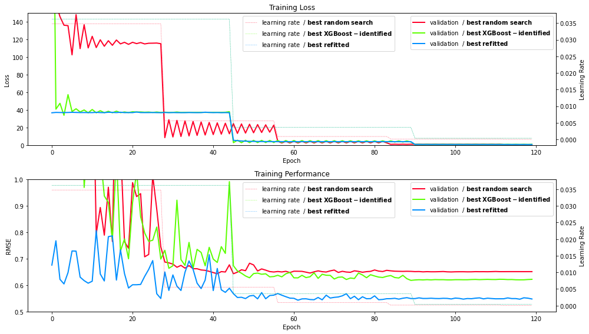

```python
from my_NLP_RNN_fr_lib.model.training import train_models
from my_NLP_RNN_fr_lib.model.plot import plot_trained_models_history

csv_full_path = os.path.join('model', 'trained_instances.csv')

trained_models_df = pd.read_csv(csv_full_path)

batch_size = 512 ; epochs = 120

best_random_20th_idx = \
    trained_models_df[
        (trained_models_df[ "batch_size" ] == batch_size) &
        (trained_models_df[ "epochs" ] == epochs) &
        (trained_models_df['is_random_set'] == 1) &
        (trained_models_df['training records'] == 7352) &
        (trained_models_df['validation records'] == 1298)]["val_rmse__last_10_avg"].idxmin()
best_xgboost_20th_idx = \
    trained_models_df[
        (trained_models_df[ "batch_size" ] == batch_size) &
        (trained_models_df[ "epochs" ] == epochs) &
        (trained_models_df['is_random_set'] == 0) &
        (trained_models_df['training records'] == 7352) &
        (trained_models_df['validation records'] == 1298)]["val_rmse__last_10_avg"].idxmin()
best_xgboost_idx = \
    trained_models_df[
        (trained_models_df[ "batch_size" ] == batch_size) &
        (trained_models_df[ "epochs" ] == epochs) &
        (trained_models_df['is_random_set'] == 0) &
        (trained_models_df['training records'] == 147061) &
        (trained_models_df['validation records'] == 25952)]["val_rmse__last_10_avg"].idxmin()

plot_trained_models_history(
    trained_models_df.loc[[
        best_random_20th_idx, best_xgboost_20th_idx, best_xgboost_idx]].reset_index(drop=True)
    , validation_only = True
    , labels = [r' / $\bf{best}$ $\bf{random}$ $\bf{search}$'
                , r' / $\bf{best}$ $\bf{XGBoost-identified}$'
                , r' / $\bf{best}$ $\bf{refitted}$']
)
```

These performances have respectively been obtained when using the below-listed sets of hyperparameters values :

```python
from my_NLP_RNN_fr_lib.display_helper import format_vertical_headers

best_models_df = \
    trained_models_df.loc[
        [best_random_20th_idx, best_xgboost_20th_idx, best_xgboost_idx]
        , trained_models_df.columns.isin([
            'training records', 'validation records', 'spatial_dropout_prop', 'recurr_units',
            'recurrent_regularizer_l1_factor', 'recurrent_regularizer_l2_factor',
            'recurrent_dropout_prop', 'conv_units', 'kernel_size_1',
            'kernel_size_2', 'dense_units_1', 'dense_units_2', 'dropout_prop', 'lr',
            'val_rmse__last_10_avg'
        ])]
best_models_df.index = ['best random search', 'best XGBoost-identified', 'best refitted']
best_models_df = \
    best_models_df.reset_index(level=0) \
    .rename(columns = {'index': 'model', 'val_rmse__last_10_avg':'valiadation RMSE'})
format_vertical_headers(
    best_models_df
    , greyed_out_colnames = ['training records', 'validation records', 'valiadation RMSE']
)
```

| model | training records | validation records | spatial_dropout_prop | recurr_units | recurrent_regularizer_l1_factor | recurrent_regularizer_l2_factor | recurrent_dropout_prop | conv_units | kernel_size_1 | kernel_size_2 | dense_units_1 | dense_units_2 | dropout_prop | lr | valiadation RMSE |
| --- | --- | --- | --- | --- | --- | --- | --- | --- | --- | --- | --- | --- | --- | --- | --- |
| best random search | 7352 | 1298 | 0.65 | 115 | 0.04136 | 0.00843 | 0.00356 | 25 | 3 | 2 | 49 | 42 | 0.22 | 0.0348 | 0.650973 |
| best XGBoost-identified | 7352 | 1298 | 0.62 | 68 | 0.03626 | 0.00635 | 0.00616 | 28 | 2 | 3 | 46 | 32 | 0.04 | 0.0362 | 0.621018 |
| best refitted | 147061 | 25952 | 0.62 | 68 | 0.03626 | 0.00635 | 0.00616 | 28 | 2 | 3 | 46 | 32 | 0.04 | 0.0362 | 0.549117 |

However tedious, the process followed to get to the optimized set of hyperparameters values for our NLP model architecture represents a dramatic enhancement in performance compared to the best we could come up with using pure random search.

## 5. NLP Model Training *(go back to top ↑)]*

As explained in the summary figure seen in **§0.**, we follow a 3-Steps process to train our Fench Sentiment NLP model :

- Step 1 : pre-training
- Step 2 : warming-up
- Step 3 : fine-tuning

### 5.1. Pre-training *(go back to top ↑)]*

For the pre-training of our French Sentiment NLP model, we work with the French Reviews dataset (that we web-scrapped, as explained **§2.1.**). We detail here what we basically did to train the "**best-refitted**" model instance mentioned in **§4.2.** above.  
Below, we start by splitting the French Reviews dataset into 'training' and 'validation' subsets :

```python
reviews_X = \
    sentences_to_indices(reviews['comment'], word_to_index, max_len = TWEET_MAX_CHAR_COUNT)
reviews_Y = \
    reviews['rating']
#del reviews ; silent = gc.collect()
```

```python
from sklearn.model_selection import train_test_split

test_prop = .15
X_train, X_valid, y_train, y_valid = \
    train_test_split(reviews_X, reviews_Y,
                     test_size=test_prop)
```

Our training sample is made up of 147,061 records and we have 25,952 additional ones for validation purposes. We use the *keras.optimizers.RMSprop* optimizer., We employ learning rate decay. Our loss function is the MeanSquarredError function. And our performance metric is the RootMeanSquaredError metric.  
It has all been wrapped-up within the **add_trained_model** convenience method that is part of the *my_NLP_RNN_fr_lib.model.training* module

[figure not shown]

.  
Information pertaining to each of the NLP model trained instances are stored on-the-fly in a dedicated global csv file.

To save on space, saved NLP model instances are not made available here but running the below cell would retrain the best performing one of them and save it locally :

```
from my_NLP_RNN_fr_lib.model.training import add_trained_model

csv_full_path = os.path.join('model', 'trained_instances.csv')
save_root = os.path.join('model', 'trained_instances')

trained_model_timestamp = add_trained_model(
    (X_train, X_valid, y_train, y_valid)
    , word_to_vec_map, word_to_index
    , **trained_models_df.loc[best_xgboost_idx, trained_models_df.columns.isin([
        'spatial_dropout_prop', 'recurr_units',
        'recurrent_regularizer_l1_factor', 'recurrent_regularizer_l2_factor',
        'recurrent_dropout_prop', 'conv_units', 'kernel_size_1',
        'kernel_size_2', 'dense_units_1', 'dense_units_2', 'dropout_prop', 'lr',
       'lr_decay_rate', 'lr_decay_step', 'batch_size', 'epochs'
    ])]
    , local_path = save_root, csv_full_path = csv_full_path
)
```

Any trained instance of our NLP model can then be reloaded as shown below :

```python
from keras.models import load_model
from my_NLP_RNN_fr_lib.model.training import root_mean_squared_error

if 'trained_model_timestamp' in locals() :
    if not trained_model_timestamp :
        trained_model_timestamp = trained_models_df.loc[best_xgboost_idx, 'timestamp']
else :
    trained_model_timestamp = trained_models_df.loc[best_xgboost_idx, 'timestamp']

custom_objects={'root_mean_squared_error': root_mean_squared_error}
trained_model = load_model(
    os.path.join('model', 'trained_instances', trained_model_timestamp
                 , 'model_' + trained_model_timestamp + '_last.h5')
    , custom_objects = custom_objects
)
```

Now that we have an optimum trained instance of our NLP model, we can start looking into some French Reviews ratings predictions. Lets randomly pick 10 from our training dataset :

```python
import random

rows = random.sample(list(reviews.index), reviews_sample_size)

predicted_ratings = trained_model.predict(reviews_X[rows])
#[(predicted_rating[0], int(round(predicted_rating[0]))) for predicted_rating in predicted_ratings]
```

| rating | review | predicted rating (rounded) |
| --- | --- | --- |
| 3 | Un restaurant de spécialités sénégalaise sans prétention mais c'est bon et correct au niveau tarif. | 2 |
| 5 | Tout était excellent! Les décors, les acteurs, l'histoire. En bref, c'est un très bon film. Ce qui ne m'a pas plu: Rien du tout. | 4 |
| 2 | l'innocence, la magie, la nostalgie, la fausse naiveté Ce qui ne m'a pas plu: un peu cucul par moment et démodé | 4 |
| 3 | la transposition à l'écran d'un fait divers qui tend à se banaliser Ce qui ne m'a pas plu: quelques longueurs et certains roles qui ne sonnent pas justes | 3 |
| 4 | très romantique | 3 |
| 4 | Joli cadre moderne avec une terrasse dans le même ton et une qualité de galette surprenante. | 3 |
| 5 | Couteau au top-Coupe bien, se nettoie bien, très jolie sur le plan de travail | 3 |
| 4 | Pas déçue, le livre est bien respecté. je doutais du choix des acteur et au final ils sont parfaits. j'ai passé un agréable moment. | 4 |
| 4 | j'ai tout apprécié dans ce film, la mise en scène, lesmagnifiques paysages d' Egypte tout comme le Jardin des Plantes, ainsi que le jeux des acteurs souvent difficiles à reconnaitre (Mr Almaric). Avec… | 4 |
| 5 | Très beau film et admirablement interprété, mais surtout n'oubliez pas votre mouchoir | 4 |

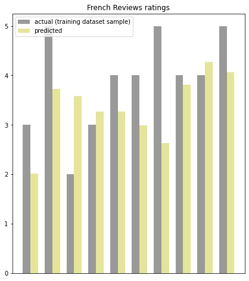

```python
# table
sampled_results = \
    pd.concat((pd.DataFrame(reviews.loc[rows, ['rating', 'comment']].values)
              , pd.DataFrame({2: [int(round(pred[0])) for pred in predicted_ratings]}))
             , axis = 1)
sampled_results = \
    sampled_results.apply(lambda x: (x[0], html_escape(x[1]), x[2])
                          , axis=1, result_type='expand') \
    .rename(columns = {0:'rating', 1:'review', 2: 'predicted rating (rounded)'})

# plot
plt.ioff() ; fig = plt.figure(figsize=(7, 8))
ax = plt.gca()
x_index = np.arange(reviews_sample_size)
bar_width = 0.35
ax.bar(x_index, reviews_Y[rows]
       , bar_width, label="actual (training dataset sample)", color='black', alpha=.4)
ax.bar(x_index + bar_width, predicted_ratings.reshape((reviews_sample_size,))
       , bar_width, label="predicted", color='y', alpha=.4)
ax.set_title("French Reviews ratings")
ax.legend()
ax.get_xaxis().set_visible(False)
#plt.show()

if not os.path.isdir(os.path.join('tmp')) : os.makedirs('tmp')
title = "reviews_predictions"
fig_url = os.path.join('tmp', title+".jpg")
plt.savefig(fig_url, bbox_inches='tight') ; plt.close(fig)

# use base64 encoding to circumvent image (external file) caching (webbrowser)
with open(fig_url, "rb") as image_file:
    encoded_string = base64.b64encode(image_file.read())
encoded_string = "data:… " + encoded_string.decode()
os.remove(fig_url)

two_columns_display(sampled_results.style.hide_index().set_table_styles(
            [dict(selector="th", props=[('text-align','center')])]
        ).render(), '<img src="' + encoded_string + '" />', .55)
```

That's all for the pre-training of our NLP model. We're now in a position to transfer that knowledge our model has acquired from the rather generic domain that our web-scrapped French Reviews dataset consitutes and use it as a learning starting point for our (smaller ; soccer-specific) target French Tweets dataset.

### 5.2. Warming-Up *(go back to top ↑)]*

#### 5.2.a. Training / Validation / Holdout data subsetting *(go back to top ↑)]*

In the pre-training phase (**§5.1.** above), transfer Learning took place on the French Reviews dataset. The warming-up phase here, on the other hand, takes place on our target French Tweets dataset. As seen in **§1.3.** , this dataset is made up of three sentiment classes which are "NEGATIVE", "NEUTRAL" and "POSITIVE".

```python
tweets_X = \
    sentences_to_indices(tweets['tweet_text'], word_to_index, max_len = TWEET_MAX_CHAR_COUNT)
tweets_Y = \
    tweets['sentiment']
```

If we recall from **§1.3.** above, the French Tweets dataset being highly imbalanced, it needs **downsampling** to address the fact that the "NEUTRAL" sentiment class is way over-represented. But prior to doing that, in order to evaluate fairly the performance of our model, we need splitting our real-life dataset into training / validation / holdout subsets.  
This operation has to take place now, since we indeed want to respect the elementary rules of model training which are :

- we measure the final performance of a model on :
  1. data it had never been presented before (the holdout subset),
  2. data drawn from the real life distribution it will have to predict from when deployed into production (no alteration of the resampling kind),
- the validation and holdout datasets MUST be drawn from identical distributions,
- it is acceptable to **train** a model on manipulated data (using techinques such as oversampling/undersampling or data augmentation)

```python
from sklearn.model_selection import train_test_split

test_prop = .15 ; holdout_size = 3000
tweets_X_train, tweets_X_valid, tweets_y_train, tweets_y_valid = \
    train_test_split(tweets_X, tweets_Y,
                     test_size=test_prop)
tweets_X_valid, tweets_X_holdout, tweets_y_valid, tweets_y_holdout = \
    train_test_split(tweets_X_valid, tweets_y_valid,
                     test_size=holdout_size)
```

We thus take 85% of our French Tweets and will downsample these 186,659 records and will use the result of that for training. Save the 3,000 records which constitute our holdout data, the remaing 15% are to be used for validation (making it 29,940 validation records).  
It is on the training dataset (and on the training dataset only) that we operate resampling. We employ **downsampling** on the French Tweets dataset to address the fact that the "NEUTRAL" sentiment class is way over-represented there. This results in the below classes distribution for our resized training dataset :

```python
from imblearn.under_sampling import RandomUnderSampler

rus = RandomUnderSampler( sampling_strategy={'NEUTRAL':tweets_y_train[tweets_y_train == 'POSITIVE'].count()})
tweets_X_train_resampled, tweets_y_train_resampled = rus.fit_sample(tweets_X_train, tweets_y_train )
```

| sentiment | count | percentage |
| --- | --- | --- |
| NEGATIVE | 5,164 | 8.80% |
| NEUTRAL | 26,758 | 45.60% |
| POSITIVE | 26,758 | 45.60% |

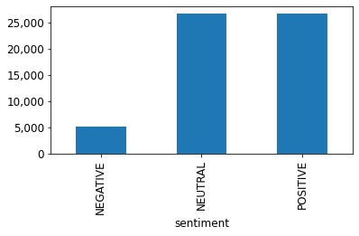

```python
two_columns_display__classes_distribution( tweets_y_train_resampled )
```

The resulting dataset is still too widely biased against NEGATIVE tweets, though. If we were to train a model on it, it would neglect to learn to detect NEGATIVE instances altogether. To adress that, we now choose to use **upsampling**. There are indeed too few NEGATIVE records for us to use downsampling again. The resulting training dataset would become way too small for any learning to happen otherwise.

```python
from imblearn.over_sampling import RandomOverSampler

ros = RandomOverSampler( 'not majority' )
tweets_X_train_resampled, tweets_y_train_resampled = ros.fit_sample(tweets_X_train_resampled, tweets_y_train_resampled)
```

Following the principles listed above, we end up with the below 3 data subsets :

```
Training dataset
```

| sentiment | count | percentage |
| --- | --- | --- |
| NEGATIVE | 26,758 | 33.33% |
| NEUTRAL | 26,758 | 33.33% |
| POSITIVE | 26,758 | 33.33% |

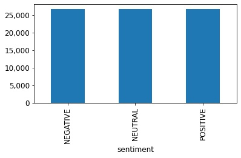

```
Validation dataset
```

| sentiment | count | percentage |
| --- | --- | --- |
| NEGATIVE | 843 | 2.82% |
| NEUTRAL | 24,821 | 82.90% |
| POSITIVE | 4,276 | 14.28% |

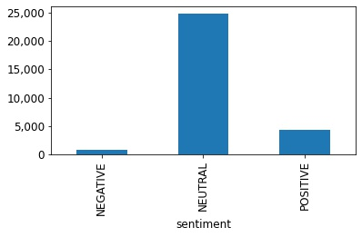

```
Holdout dataset
```

[output not shown]

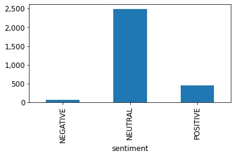

```python
print('\033[1m' + '\033[4m' + 'Training' + '\033[0m' + '\033[1m' + ' dataset' + '\033[0m')
two_columns_display__classes_distribution( tweets_y_train_resampled )
print('\033[1m' + '\033[4m' + 'Validation' + '\033[0m' + '\033[1m' + ' dataset' + '\033[0m')
two_columns_display__classes_distribution( tweets_y_valid )
print('\033[1m' + '\033[4m' + 'Holdout' + '\033[0m' + '\033[1m' + ' dataset' + '\033[0m')
two_columns_display__classes_distribution( tweets_y_holdout )
```

#### 5.2.b. model training *(go back to top ↑)]*

```python
tweets_y_train_resampled_1_hot = \
    pd.get_dummies( tweets_y_train_resampled ) #One-Hot encoded
tweets_y_valid_1_hot = \
    pd.get_dummies( tweets_y_valid ) #One-Hot encoded
tweets_y_holdout_1_hot = \
    pd.get_dummies( tweets_y_holdout ) #One-Hot encoded
```

During the pre-training phase, we had 5 (ordered) classes. Thus, as introduced in **§2.1.**, we legitimately handeled the Sentiment Analysis problem as a regression problem. It translated in having a relu-activated 1 Node Dense output layer.  
For the remaining of the training process of our NLP model, the target dataset is made-up of 3 classes where we can't really consider any hierarchy. We then now use a softmax-activated 3 Nodes Dense output layer :

```python
from keras.models import Model
from keras.layers import Dense

o = Dense(3, activation = "softmax", name = "tweets_sentiment")(trained_model.layers[-2].output) # ignore original last layer

tweets_model = Model( inputs = trained_model.input, outputs = [o])
#tweets_model.summary()
```

Remember that we are using the architecture depicted in **§4.1.** above. With our optimum set of hyperparameter values, for each input sentence (of maximum length 280), the inner tensors of our NLP model are of the shapes listed in the below table. Note that, for the warming-up of our model with its new output, we freeze all layers except the (new) very last one. This represents the "**Step 2**" in the summary figure seen in **§0.** :

```python
for layer in tweets_model.layers[:-1] :
    layer.trainable = False

layers_df = pd.DataFrame()
for layer in tweets_model.layers :
    layers_df = layers_df.append([[str(layer.__class__).split('.')[-1][:-2], str(layer.input_shape).replace('None, ', '')
                                   , str(layer.output_shape).replace('None, ', ''), layer.trainable]]
                                 , ignore_index = True, verify_integrity=False
    )
layers_df.columns=['class', 'input_shape', 'output_shape', 'trainable']
dataframe_pretty_print_center(layers_df)
```

| class | input_shape | output_shape | trainable |
| --- | --- | --- | --- |
| InputLayer | (280) | (280) | False |
| Embedding | (280) | (280, 300) | False |
| SpatialDropout1D | (280, 300) | (280, 300) | False |
| Bidirectional | (280, 300) | (280, 136) | False |
| Bidirectional | (280, 300) | (280, 136) | False |
| Conv1D | (280, 136) | (279, 28) | False |
| Conv1D | (280, 136) | (278, 28) | False |
| Conv1D | (280, 136) | (279, 28) | False |
| Conv1D | (280, 136) | (278, 28) | False |
| GlobalMaxPooling1D | (279, 28) | (28) | False |
| GlobalMaxPooling1D | (278, 28) | (28) | False |
| GlobalMaxPooling1D | (279, 28) | (28) | False |
| GlobalMaxPooling1D | (278, 28) | (28) | False |
| Concatenate | [(28), (28), (28), (28)] | (112) | False |
| BatchNormalization | (112) | (112) | False |
| Dense | (112) | (46) | False |
| Dropout | (46) | (46) | False |
| BatchNormalization | (46) | (46) | False |
| Dense | (46) | (32) | False |
| Dropout | (32) | (32) | False |
| Dense | (32) | (3) | True |

We perform our model warming-up using the same setup as the one we'll use next, during the fine-tuning of our model. That is that we use 'categorical_crossentropy' as our loss function, *keras.optimizers.Adam* as our optimizer, we do measure not only 'accuracy' (not that meaningful with imbalanced datasets) but also 'precision' and 'recall', both globally and per class :

```python
from tqdm.keras import TqdmCallback
from keras.optimizers import Adam
from keras.metrics import Precision, Recall, CategoricalCrossentropy, CategoricalAccuracy
# f1_score = 2*(precision*recall)/(precision+recall+K.epsilon())

warming_up_lr=0.001 # default: 0.01
optimizer = Adam( learning_rate = warming_up_lr )
metrics = [CategoricalCrossentropy(), CategoricalAccuracy()
           , Precision(name='precision'), Recall(name='recall')
           , Precision(name='precision_NEG', class_id=0), Recall(name='recall_NEG', class_id=0)
           , Precision(name='precision_NEUT', class_id=1), Recall(name='recall_NEUT', class_id=1)
           , Precision(name='precision_POS', class_id=2), Recall(name='recall_POS', class_id=2)
          ]

tweets_model.compile(loss='categorical_crossentropy', optimizer=optimizer, metrics=metrics)
```

```python
verbose = 1
warming_up_history = \
    tweets_model.fit(tweets_X_train_resampled, tweets_y_train_resampled_1_hot
                     , batch_size = 1024, epochs=15
                     , validation_data=(tweets_X_valid, tweets_y_valid_1_hot)
                     , verbose = 0
                     , callbacks = [TqdmCallback(verbose=verbose)]
                    )
```

[figure not shown]

- 15/15 [16:55<00:00, 67.70s/epoch, val_loss=1.54, val_categorical_crossentropy=1.13, val_categorical_accuracy=0.165, val_precision=0, val_recall=0, val_precision_NEG=0, val_recall_NEG=0, val_precision_NEUT=0, val_recall_NEUT=0, val_precision_POS=0, val_recall_POS=0, loss=1.51, categorical_crossentropy=1.09, categorical_accuracy=0.368, precision=0.485, recall=0.00517, precision_NEG=0, recall_NEG=0, precision_NEUT=0.487, recall_NEUT=0.0153, precision_POS=0.583, recall_POS=0.000263]

The whole idea behind warming-up consists in bootstrapping the transfer learning. We do that by assigning weights to the new output layer that are more optimum than the initial random values. By freezing all the preceeding layers, the optimizer focuses and these last weights alone, which gives them a huge advantage when later actually operating the model fine-tuning in the upcoming section.

### 5.3. Fine-Tuning *(go back to top ↑)]*

Now that our model has learned from a generic large corpus of french texts and that our new output layer has been warmed-up on the target French Tweets dataset, the actual fine-tuning of our French Sentiment NLP model can start. Lets first "un-freeze" the model's inner layer :

```python
for layer in tweets_model.layers[2:] :
    layer.trainable = True

layers_df = pd.DataFrame()
for layer in tweets_model.layers :
    layers_df = layers_df.append([[str(layer.__class__).split('.')[-1][:-2], str(layer.input_shape).replace('None, ', '')
                                   , str(layer.output_shape).replace('None, ', ''), layer.trainable]]
                                 , ignore_index = True, verify_integrity=False
    )
layers_df.columns=['class', 'input_shape', 'output_shape', 'trainable']
dataframe_pretty_print_center(layers_df)
```

| class | input_shape | output_shape | trainable |
| --- | --- | --- | --- |
| InputLayer | (280) | (280) | False |
| Embedding | (280) | (280, 300) | False |
| SpatialDropout1D | (280, 300) | (280, 300) | True |
| Bidirectional | (280, 300) | (280, 136) | True |
| Bidirectional | (280, 300) | (280, 136) | True |
| Conv1D | (280, 136) | (279, 28) | True |
| Conv1D | (280, 136) | (278, 28) | True |
| Conv1D | (280, 136) | (279, 28) | True |
| Conv1D | (280, 136) | (278, 28) | True |
| GlobalMaxPooling1D | (279, 28) | (28) | True |
| GlobalMaxPooling1D | (278, 28) | (28) | True |
| GlobalMaxPooling1D | (279, 28) | (28) | True |
| GlobalMaxPooling1D | (278, 28) | (28) | True |
| Concatenate | [(28), (28), (28), (28)] | (112) | True |
| BatchNormalization | (112) | (112) | True |
| Dense | (112) | (46) | True |
| Dropout | (46) | (46) | True |
| BatchNormalization | (46) | (46) | True |
| Dense | (46) | (32) | True |
| Dropout | (32) | (32) | True |
| Dense | (32) | (3) | True |

We're now ready for "**Step 3**" of the summary figure seen in **§0.**, i.e. the actual fine-tuning of our French NLP model :

```python
fine_tuning_lr = 0.001
optimizer = Adam( learning_rate = fine_tuning_lr )
tweets_model.compile(loss='categorical_crossentropy', optimizer=optimizer, metrics=metrics)
```

```python
from keras.callbacks import LearningRateScheduler
from my_NLP_RNN_fr_lib.model.callbacks import LearningRatePrinter, lr_sheduler_func

my_learning_rate_printer = LearningRatePrinter()

learning_rates_decays = {30: .1, 40: .1}
my_lr_scheduler = LearningRateScheduler(
    lr_sheduler_func(learning_rates_decays = learning_rates_decays
                     , learning_rate_printer = my_learning_rate_printer))

verbose = 1
callbacks = [my_lr_scheduler, my_learning_rate_printer, TqdmCallback(verbose=verbose)]

fine_tuning_history = \
    tweets_model.fit(tweets_X_train_resampled, tweets_y_train_resampled_1_hot
                     , batch_size = 512, epochs=45
                     , validation_data=(tweets_X_valid, tweets_y_valid_1_hot)
                     , verbose = 0, callbacks = callbacks)
```

[figure not shown]

- 45/45 [2:03:59<00:00, 165.33s/epoch, val_loss=0.869, val_categorical_crossentropy=0.867, val_categorical_accuracy=0.63, val_precision=0.734, val_recall=0.508, val_precision_NEG=0.0952, val_recall_NEG=0.339, val_precision_NEUT=0.942, val_recall_NEUT=0.549, val_precision_POS=0.426, val_recall_POS=0.318, loss=0.942, categorical_crossentropy=0.94, categorical_accuracy=0.547, precision=0.632, recall=0.375, precision_NEG=0.575, recall_NEG=0.374, precision_NEUT=0.694, recall_NEUT=0.479, precision_POS=0.619, recall_POS=0.272, lr=1e-5]

epoch 0 ; lr: 0.001000  
epoch 30 ; lr: 0.000100  
epoch 40 ; lr: 0.000010

Lets visualize the history of our 2-phases training. In the below figure, the grayed-out area represents the warming-up. The remaining covers the fine-tuning phase :

```python
warming_up_history_df = warming_up_history.history
fine_tuning_history_df = fine_tuning_history.history
```

```python
from my_NLP_RNN_fr_lib.model.plot import warming_up_fine_tuning_history

fig1, fig2 = warming_up_fine_tuning_history(
    warming_up_history_df, warming_up_lr, fine_tuning_history_df
    , fig1_size=(6, 14), fig2_size=(6, 18)
)# ; plt.show()

fig_path = os.path.join('.', 'images')
fig1.savefig(os.path.join(fig_path, 'tweets_model_history.png'), bbox_inches='tight')
plt.close(fig1)
fig2.savefig(os.path.join(fig_path, 'tweets_model_classes_history.png'), bbox_inches='tight')
plt.close(fig2)
```

[figure not shown]

[figure not shown]

.

Now that the training of our French Sentiment NLP model has been completed, it is time to independently measure how good it is actuially performing and there's no better way to do that than to predict some French Tweets sentiment from a real-life data distribution that had never been presented to that model before ; the holdout dataset :

```python
predictions_1_hot = tweets_model.predict(tweets_X_holdout)
```

```python
from sklearn.metrics import confusion_matrix

cm_df = pd.DataFrame(
    confusion_matrix(tweets_y_holdout_1_hot.to_numpy().argmax(axis=1)
                     , predictions_1_hot.argmax(axis=1))
)
cm_df.columns = cm_df.index = tweets_y_holdout_1_hot.columns
cm_html = cm_df.to_html(formatters={'NEUTRAL': '{:,}'.format})
```

```python
from sklearn.metrics import classification_report
from my_NLP_RNN_fr_lib.display_helper import classification_report_pretty_html

report_dict = \
    classification_report(tweets_y_holdout_1_hot.to_numpy().argmax(axis=1)
                          , predictions_1_hot.argmax(axis=1)
                          , target_names = tweets_y_holdout_1_hot.columns
                          , zero_division  = 1
                          , output_dict = True)

report_html = classification_report_pretty_html(report_dict)
```

```python
print('Performance of the final model on the holdout dataset :')
two_columns_display('<br /><br /><div>Confusion Matrix</div>' + cm_html
                    , '<div>Classification Report</div>' + report_html, left_ratio  = .4)
```

```
Performance of the final model on the holdout dataset :
```

Confusion Matrix

|  | NEGATIVE | NEUTRAL | POSITIVE |
| --- | --- | --- | --- |
| NEGATIVE | 61 | 18 | 10 |
| NEUTRAL | 500 | 1,705 | 282 |
| POSITIVE | 115 | 124 | 185 |

Classification Report

|  | precision | recall | f1-score | support |
| --- | --- | --- | --- | --- |
| NEGATIVE | 0.09 | 0.69 | 0.16 | 89 |
| NEUTRAL | 0.92 | 0.69 | 0.79 | 2,487 |
| POSITIVE | 0.39 | 0.44 | 0.41 | 424 |
| accuracy |  |  | 0.65 | 3,000 |
| macro avg | 0.47 | 0.60 | 0.45 | 3,000 |
| weighted avg | 0.82 | 0.65 | 0.72 | 3,000 |

As the Confusion Matrix and the Classification Report show it above :

- the overall Precision of our model stands at the more than honorable level of 82%. Despite all of our efforts, it does however still vary a lot accross classes. For example, **when our model predicts a French Tweet to be 'NEGATIVE', it is correct only 9% of the time**. This is undesirable and shall increase when more training data becomes available.
- if the overall Recall of our model is a little less impressive than its Precision with an however still respectable 65%, it is more even accross classes than the latter. **Regarding NEGATIVE French Tweets for instance, our NLP model succesfully identifies them 69% of the time. This is an impressive performance considering such an imbalanced real-life data distribution (and the tiny total occurences of NEGATIVE records in the entire population)** .

backup

```python
import dill as pickle
root = os.path.realpath(os.path.join('.', 'model', 'tweets_model'))
```

```python
with open(os.path.join(root, "model.json"), "w") as json_file :
    json_file.write(tweets_model.to_json())
tweets_model.save_weights(os.path.join(root, 'model_weights.h5'))

with open(os.path.join(root, 'warming_up_history_df.pickle'), 'wb') as file_pi:
    pickle.dump(warming_up_history.history, file_pi)

with open(os.path.join(root, 'fine_tuning_history_df.pickle'), 'wb') as file_pi:
    pickle.dump(fine_tuning_history.history, file_pi)
```

reload

```python
from keras.models import model_from_json

with open(os.path.join(root, "model.json"), 'r') as json_file :
    loaded_model_json = json_file.read()
tweets_model = model_from_json(loaded_model_json)
tweets_model.load_weights(os.path.join(root, 'model_weights.h5'))

with open(os.path.join(root, 'warming_up_history_df.pickle'), 'rb') as file_pi:
    warming_up_history_df = pickle.load(file_pi)

with open(os.path.join(root, 'fine_tuning_history_df.pickle'), 'rb') as file_pi:
    fine_tuning_history_df = pickle.load(file_pi)
```

## 6. Conclusion *(go back to top ↑)]*

NLP models on languages others than English are seldom. And it's mostly because labelled data in those languages is hard to come by.

The project of the herein notebook being Sentiment Classification on French Texts, we've covered many aspects of techniques that can be handy when working on real-world data which can often be imperfect and/or costly to acquire :

- we've seen the power of transfer learning from web-scrapped, rather generic, French Reviews to domain-specific French Tweets (specific to soccer in our use case).
- we've also used XGBoost as a supercharger to our hyperparameters optimization (in this separate dedicated notebook

[figure not shown]

  )
- we've also covered means at our disposal when dealing with highly imbalanced datasets

The above-depicted technical "tricks" in our toolset allowed to train a dual bi-GRU model architecture in an optimum fashion for such a model to tackle efficiently some everyday-life problems.

Ours here is *domain-specific to soccer*, but any public or private organization could "tune" our model, for instance on a brand-specific dataset (which it would posess internally), by simply following **§5.2.** & **§5.3.**, which is really quick. Such an NLP model would for instance be a well suited technical solution for anyone willing to implement an automatic Twitter monitoring system for a brand operating on French-speaking markets. This would allow to identify any potential "bad buzz" on the social media platform around the brand as-soon-as any ever occurs. On the other hand, being notified on POSITIVE French Tweets would for instance allow to implement a targetted promotional campaign involving enthousiastic/supportive customers and thus build a resilient community around the brand.

# EXTRA

**Export Notebook to HTML (with Markdown extension cells evaluated)**

```python
from my_NLP_RNN_fr_lib.jupyter_markdown_extension import md_extension_to_html

md_extension_to_html(os.path.join(os.path.realpath('.'), 'main.ipynb'))
```

```
'main.ipynb' ; 'D:\jupyter_notebooks\NLP_Sentiment_Analysis_French\main.html'
done.
```